# ProjectStage2

## 1. Introduction

Student Name: Yexuan Gao

```python
import numpy as np
import matplotlib.pyplot as plt
import pandas as pd
import seaborn as sns
plt.style.use('fivethirtyeight')
%matplotlib inline
```

```python
from google.colab import drive
drive.mount('/content/drive')
```

```python
%cd '/content/drive/MyDrive/tcss551/project/'
```

```
/content/drive/MyDrive/tcss551/project
```

### 1.1 Revision to Stage-1

#### 1.1.a Kaggle Account Name: Yexuan G.

#### 1.1.b Structure of Data

From the result of the following code blocks, the data here is rectangularly shaped containing (string, int, float) value. Each row represent a record of a person on the titanic.

Data type of each feature:

'PassengerId', int

'Survived', int

'Pclass', int

'Name', string

'Sex', string

'Age', float

'SibSp', int

'Parch', int

'Ticket', string

'Fare', float

'Cabin', string/NaN

'Embarked', string

```python
import os
titanic_data_file = 'titanic-data/train.csv'

print("Titanic Data ------------------")
with open(titanic_data_file, 'r') as f:
  for i in range(15):
    print(f.readline())
```

```
Titanic Data ------------------
PassengerId,Survived,Pclass,Name,Sex,Age,SibSp,Parch,Ticket,Fare,Cabin,Embarked

1,0,3,"Braund, Mr. Owen Harris",male,22,1,0,A/5 21171,7.25,,S

2,1,1,"Cumings, Mrs. John Bradley (Florence Briggs Thayer)",female,38,1,0,PC 17599,71.2833,C85,C

3,1,3,"Heikkinen, Miss. Laina",female,26,0,0,STON/O2. 3101282,7.925,,S

4,1,1,"Futrelle, Mrs. Jacques Heath (Lily May Peel)",female,35,1,0,113803,53.1,C123,S

5,0,3,"Allen, Mr. William Henry",male,35,0,0,373450,8.05,,S

6,0,3,"Moran, Mr. James",male,,0,0,330877,8.4583,,Q

7,0,1,"McCarthy, Mr. Timothy J",male,54,0,0,17463,51.8625,E46,S

8,0,3,"Palsson, Master. Gosta Leonard",male,2,3,1,349909,21.075,,S

9,1,3,"Johnson, Mrs. Oscar W (Elisabeth Vilhelmina Berg)",female,27,0,2,347742,11.1333,,S

10,1,2,"Nasser, Mrs. Nicholas (Adele Achem)",female,14,1,0,237736,30.0708,,C

11,1,3,"Sandstrom, Miss. Marguerite Rut",female,4,1,1,PP 9549,16.7,G6,S

12,1,1,"Bonnell, Miss. Elizabeth",female,58,0,0,113783,26.55,C103,S

13,0,3,"Saundercock, Mr. William Henry",male,20,0,0,A/5. 2151,8.05,,S

14,0,3,"Andersson, Mr. Anders Johan",male,39,1,5,347082,31.275,,S
```

```python
titanic_df = pd.read_csv(titanic_data_file)
titanic_df.head()
# show data type for each feature
print(titanic_df.columns.tolist())
print([type(titanic_df[i].iloc[0]) for i in titanic_df.columns.tolist()])
```

```
['PassengerId', 'Survived', 'Pclass', 'Name', 'Sex', 'Age', 'SibSp', 'Parch', 'Ticket', 'Fare', 'Cabin', 'Embarked']
[<class 'numpy.int64'>, <class 'numpy.int64'>, <class 'numpy.int64'>, <class 'str'>, <class 'str'>, <class 'numpy.float64'>, <class 'numpy.int64'>, <class 'numpy.int64'>, <class 'str'>, <class 'numpy.float64'>, <class 'float'>, <class 'str'>]
```

## 1.2 EDA and Data Transformation

#### EDA

First, we would like to know the number of unique values and missing values for each features. We will summarize the numerical and categorical data separately.

```python
titanic_df.describe() # numerical data summary
```

|  | PassengerId | Survived | Pclass | Age | SibSp | Parch | Fare |
| --- | --- | --- | --- | --- | --- | --- | --- |
| count | 891.000000 | 891.000000 | 891.000000 | 714.000000 | 891.000000 | 891.000000 | 891.000000 |
| mean | 446.000000 | 0.383838 | 2.308642 | 29.699118 | 0.523008 | 0.381594 | 32.204208 |
| std | 257.353842 | 0.486592 | 0.836071 | 14.526497 | 1.102743 | 0.806057 | 49.693429 |
| min | 1.000000 | 0.000000 | 1.000000 | 0.420000 | 0.000000 | 0.000000 | 0.000000 |
| 25% | 223.500000 | 0.000000 | 2.000000 | 20.125000 | 0.000000 | 0.000000 | 7.910400 |
| 50% | 446.000000 | 0.000000 | 3.000000 | 28.000000 | 0.000000 | 0.000000 | 14.454200 |
| 75% | 668.500000 | 1.000000 | 3.000000 | 38.000000 | 1.000000 | 0.000000 | 31.000000 |
| max | 891.000000 | 1.000000 | 3.000000 | 80.000000 | 8.000000 | 6.000000 | 512.329200 |

```python
titanic_df.describe(include=['O']) # categorical data summary
```

|  | Name | Sex | Ticket | Cabin | Embarked |
| --- | --- | --- | --- | --- | --- |
| count | 891 | 891 | 891 | 204 | 889 |
| unique | 891 | 2 | 681 | 147 | 3 |
| top | Braund, Mr. Owen Harris | male | 347082 | B96 B98 | S |
| freq | 1 | 577 | 7 | 4 | 644 |

From the above summarization and Stage 1 we can see there are some missing values in columns 'Age', 'Cabin' and 'Embarked'. 'Cabin' column has 77% missing values. These columns need to be handled separately.

Next, we know that in the training dataset, the ratio of classes of 'Survived' is also not balanced, leading to using stratified sampling in the training step.

```python
# show the proportion of 'Survived' classes
print(titanic_df['Survived'].value_counts())
```

```
Survived
0    549
1    342
Name: count, dtype: int64
```

#### 1.2.a Data Transformation

- Due to the skewed data and minimizing effect from outlier (mean = 29, max = 80), fill in the empty 'Age' entries with the median of the age instead of mean.
- Despite the high missing rate of column 'Cabin', it could provide information related to a passenger's representational group. A cabin number is a combination of a passenger's deck label followed by a number. Hence, we can separately encode their deck labels while missing entries will be assigned a 0.*
- Map 'Sex' values to integers (male: 0, female: 1)
- Map 'Embarked' values to numerical values ('S': 0, 'C': 1, 'Q': 2)

*There should be 7 decks with passengers on Titanic according to https://www.encyclopedia-titanica.org/cabins.html

```python
# Fill missing age values with the median age
titanic_df['Age'] = titanic_df['Age'].fillna(titanic_df['Age'].median())

# Separate the first character from the Cabin column
titanic_df['Cabin'] = titanic_df['Cabin'].fillna('U0')
titanic_df['Cabin'] = titanic_df['Cabin'].apply(lambda x: x[0] if x is not None else 'U')
# Map Cabin to numeric values
titanic_df['Cabin'] = titanic_df['Cabin'].map({'A': 1, 'B': 2, 'C': 3, 'D': 4, 'E': 5, 'F': 6, 'G': 7, 'T': 8, 'U': 0})
# Convert Sex to numeric values (0 for male, 1 for female)

titanic_df['Sex'] = titanic_df['Sex'].map({'male': 0, 'female': 1})
# Fill in Emarked missing entries with most common value
# Map Emarked to numeric values
titanic_df['Embarked'] = titanic_df['Embarked'].fillna(titanic_df['Embarked'].mode()[0])
titanic_df['Embarked'] = titanic_df['Embarked'].map({'S': 0, 'C': 1, 'Q': 2})
```

#### 1.2.b Selected Features

Given all the features in the original dataset, there are some features are obviously not useful to predict the target.

Similarly, 'PassegnerId' and 'Name' of a passenger does not affect whether they survived.

Therefore, 'Ticket','Name' and' PassengerId' features are dropped here as they are not useful to the training.

```python
# Remove Ticket and Name columns
titanic_df.drop(['Ticket', 'Name'], axis=1, inplace=True)
# Remove PassengerId column
titanic_df.drop('PassengerId', axis=1, inplace=True)
```

#### 1.2.c Readiness of Data

The numerical features in the dataset are in different scales. 'Fare' feature has a very skewed data (from stage 1). Here we are going to normalize them with Scikit-learn minmaxScaler, as each feature must be positive

```python
from sklearn.preprocessing import MinMaxScaler

# Create a StandardScaler object
scaler = MinMaxScaler()

# Select numerical features to scale
numerical_features = ['Age', 'Fare', 'SibSp', 'Parch']

# Fit the scaler on the numerical features and transform them
titanic_df[numerical_features] = scaler.fit_transform(titanic_df[numerical_features])
```

```python
# Split the data into input features and target
from sklearn.model_selection import train_test_split
X = titanic_df.drop('Survived', axis=1)
y = titanic_df['Survived']
```

The following heat map shows that most features are not correlated.

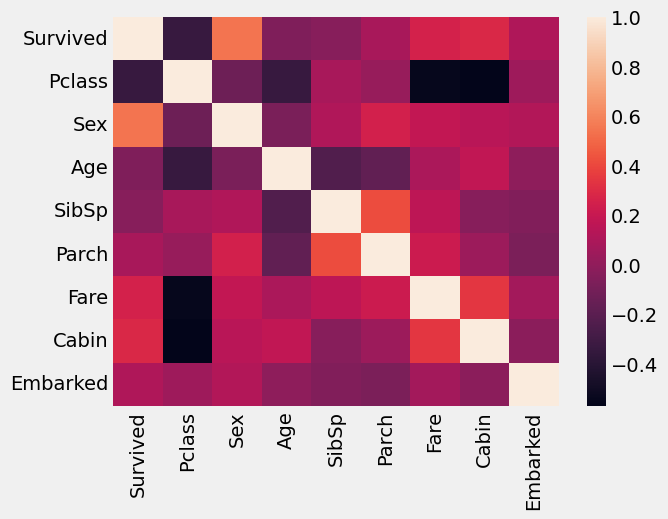

```python
# produce a heat map for each feature in the titanic_df
sns.heatmap(titanic_df.corr())
plt.show()
```

## 1.3 Modeling

#### 1.3.a Chosen Model and Selected Features

Since the task here is to predict whether the 'Survived' should be 0 or 1 based on the input features, the models shoulld be used for binary classification.

Therefore, we are goin to use Random Forest and Logistic Regression which are 2 very common and useful ML models for a classification task.

From previous data preprocessing, the input features should be:

- Pclass
- Sex
- Age
- Sibsp
- Parch
- Fare
- Cabin
- Embarked

#### 1.3.b How Features are used by the Models

Logistic Regression: calculated a weighted sum of features then apply sigmoid function to produce a likely result.

#### 1.3.d Model Estimation Results

The two selected models are trained with stratified sampling and 5-fold cross validation

Since the evaluation metric used by Kaggle for this dataset is accuracy. We will use the average accuracy of 5 folds to determine which model performs better. We will also use t-test and significance level of 0.05 to determine if one model is significantly better than the other.

```python
from sklearn.model_selection import KFold, StratifiedKFold
from sklearn.ensemble import RandomForestClassifier
from sklearn.linear_model import LogisticRegression
from sklearn.metrics import accuracy_score, precision_score, recall_score, f1_score

rf_val_accaracies = []
lr_val_accaracies = []

# Split data with stratified cross validation into 5 fold
skf = StratifiedKFold(n_splits=5, shuffle = True, random_state = 42)
for i, (train_index, val_index) in enumerate(skf.split(X, y)):
  X_train, X_val = X.iloc[train_index], X.iloc[val_index]
  y_train, y_val = y.iloc[train_index], y.iloc[val_index]


  # Initialize and train a Random Forest Classifier
  rf_classifier = RandomForestClassifier(n_estimators= 100, random_state=42)
  rf_classifier.fit(X_train, y_train)

  # Make predictions on the validation set
  rf_predictions = rf_classifier.predict(X_val)

  # Evaluate the Random Forest model
  rf_accuracy = accuracy_score(y_val, rf_predictions)
  rf_precision = precision_score(y_val, rf_predictions)
  rf_recall = recall_score(y_val, rf_predictions)
  rf_f1 = f1_score(y_val, rf_predictions)
  rf_val_accaracies.append(rf_accuracy)

  print(f"\n Fold {i}, Random Forest Classifier Accuracy: {rf_accuracy}")


  # Initialize and train a Logistic Regression Classifier
  lr_classifier = LogisticRegression(random_state=42)
  lr_classifier.fit(X_train, y_train)

  # Make predictions on the validation set
  lr_predictions = lr_classifier.predict(X_val)

  # Evaluate the Logistic Regression model
  lr_accuracy = accuracy_score(y_val, lr_predictions)
  lr_precision = precision_score(y_val, lr_predictions)
  lr_recall = recall_score(y_val, lr_predictions)
  lr_f1 = f1_score(y_val, lr_predictions)
  lr_val_accaracies.append(lr_accuracy)

  print(f"\n Fold {i}  Logistic Regression Classifier Accuracy: {lr_accuracy}")


# calculate the average accuracy of 2 models
rf_avg_acc = np.mean(rf_val_accaracies)
lr_avg_acc = np.mean(lr_val_accaracies)
print(f"\nAverage Accuracy of Random Forest Classifier: {rf_avg_acc}")
print(f"Average Accuracy of Logistic Regression Classifier: {lr_avg_acc}")
```

```
 Fold 0, Random Forest Classifier Accuracy: 0.8379888268156425

 Fold 0  Logistic Regression Classifier Accuracy: 0.8100558659217877

 Fold 1, Random Forest Classifier Accuracy: 0.8089887640449438

 Fold 1  Logistic Regression Classifier Accuracy: 0.8202247191011236

 Fold 2, Random Forest Classifier Accuracy: 0.7865168539325843

 Fold 2  Logistic Regression Classifier Accuracy: 0.8033707865168539

 Fold 3, Random Forest Classifier Accuracy: 0.8146067415730337

 Fold 3  Logistic Regression Classifier Accuracy: 0.7752808988764045

 Fold 4, Random Forest Classifier Accuracy: 0.8370786516853933

 Fold 4  Logistic Regression Classifier Accuracy: 0.8426966292134831

Average Accuracy of Random Forest Classifier: 0.8170359676103196
Average Accuracy of Logistic Regression Classifier: 0.8103257799259305
```

```python
from scipy.stats import ttest_ind

# Perform the independent samples t-test
t_statistic, p_value = ttest_ind(rf_val_accaracies, lr_val_accaracies)


print(f"T-statistic: {t_statistic}")
print(f"P-value: {p_value}")

alpha = 0.05  # Significance level

print("The performance of two models are statistically")
print("significant.\n")  if p_value < alpha else print("insignificant.\n")
print("Based on the average accuracy of the two models,")

if rf_avg_acc > lr_avg_acc:
  print("Random Forest Classifier is better than Logistic Regression Classifier")
else:
  print("Logistic Regression Classifier is better than Random Forest Classifier")
```

```
T-statistic: 0.45949112311531237
P-value: 0.6581100566508735
The performance of two models are statistically
insignificant.

Based on the average accuracy of the two models,
Random Forest Classifier is better than Logistic Regression Classifier
```

### 1.4 Inference on the Test Data for Kaggle Submission

```python
test_df = pd.read_csv('titanic-data/test.csv')
# define a data preprocessing function
def preprocess_data(df):
  df['Age'] = df['Age'].fillna(df['Age'].median())


  df['Cabin'] = df['Cabin'].fillna('U0')
  df['Cabin'] = df['Cabin'].apply(lambda x: x[0] if x is not None else 'U')

  df['Cabin'] = df['Cabin'].map({'A': 1, 'B': 2, 'C': 3, 'D': 4, 'E': 5, 'F': 6, 'G': 7, 'T': 8, 'U': 0})

  df['Sex'] = df['Sex'].map({'male': 0, 'female': 1})

  df['Embarked'] = df['Embarked'].fillna(df['Embarked'].mode()[0])
  df['Embarked'] = df['Embarked'].map({'S': 0, 'C': 1, 'Q': 2})

  df = df.drop(['Ticket', 'Name'], axis=1)

  df = df.drop('PassengerId', axis=1)

  scaler = MinMaxScaler()

  numerical_features = ['Age', 'Fare', 'SibSp', 'Parch']
  df[numerical_features] = scaler.fit_transform(df[numerical_features])
  return df
```

```python
# train a random forest on all training data set, with the same hyperparameters as before
rf_classifier = RandomForestClassifier(n_estimators= 100, random_state=42)
rf_classifier.fit(X, y)
```

```
RandomForestClassifier(random_state=42)
```

```python
# predict the target based on values from test_df with trained classifier
processed_test_df = preprocess_data(test_df)
test_predictions = rf_classifier.predict(processed_test_df)
# build dataframe with 'passengerid' from test_df and test_predictions as 'Survived'
submission_df = pd.DataFrame({'PassengerId': test_df['PassengerId'], 'Survived': test_predictions})
submission_df
```

|  | PassengerId | Survived |
| --- | --- | --- |
| 0 | 892 | 0 |
| 1 | 893 | 0 |
| 2 | 894 | 0 |
| 3 | 895 | 0 |
| 4 | 896 | 0 |
| ... | ... | ... |
| 413 | 1305 | 0 |
| 414 | 1306 | 1 |
| 415 | 1307 | 0 |
| 416 | 1308 | 0 |
| 417 | 1309 | 0 |

418 rows × 2 columns

```python
f_importance = rf_classifier.feature_importances_
feature_importances = pd.DataFrame({'feature': processed_test_df.columns, 'importance': f_importance})
feature_importances = feature_importances.sort_values('importance', ascending=False)

print(feature_importances)
```

```
    feature  importance
1       Sex    0.254586
2       Age    0.250305
5      Fare    0.243959
0    Pclass    0.071555
6     Cabin    0.061356
3     SibSp    0.049490
4     Parch    0.034427
7  Embarked    0.034321
```

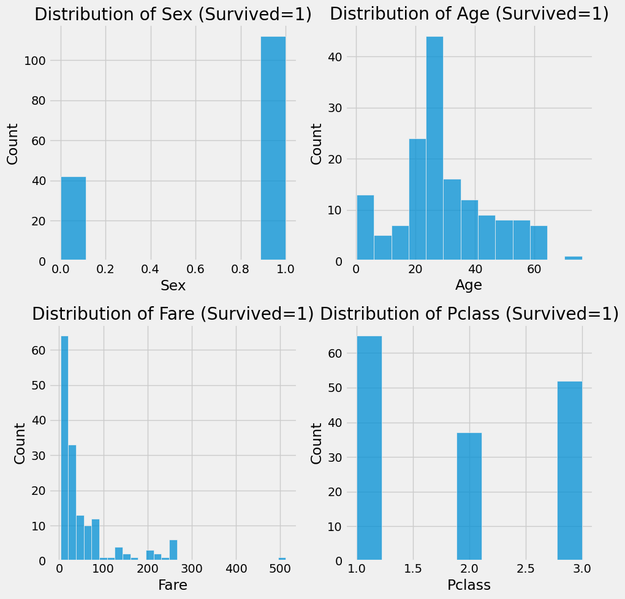

```python
# combine test predictions with processed test df
predicted_test_df = test_df.copy()
predicted_test_df['Survived'] = test_predictions

# Filter the DataFrame for survived passengers
survived_df = predicted_test_df[predicted_test_df['Survived'] == 1]

# Create the distribution plots
plt.figure(figsize=(10, 10))

plt.subplot(2, 2, 1)
sns.histplot(survived_df['Sex'])
plt.title('Distribution of Sex (Survived=1)')

plt.subplot(2, 2, 2)
sns.histplot(survived_df['Age'])
plt.title('Distribution of Age (Survived=1)')

plt.subplot(2, 2, 3)
sns.histplot(survived_df['Fare'])
plt.title('Distribution of Fare (Survived=1)')

plt.subplot(2, 2, 4)
sns.histplot(survived_df['Pclass'])
plt.title('Distribution of Pclass (Survived=1)')

plt.tight_layout()
plt.show()
```

```python
submission_df.to_csv('submission.csv', index=False)
```

#### 1.4.a Initial Kaggle Submission Result

Random Forest with 'n_estimators' = 50

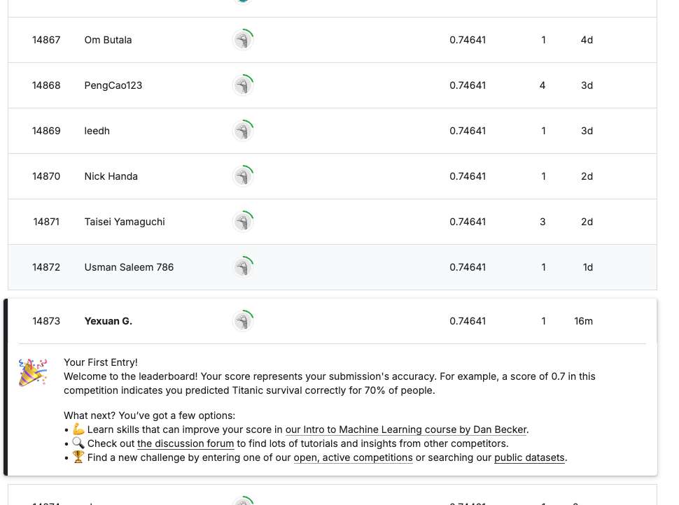

#### Additional Kaggle Submission

Improved accuracy with Random Forest with 'n_estimator' = 100

[figure not shown]

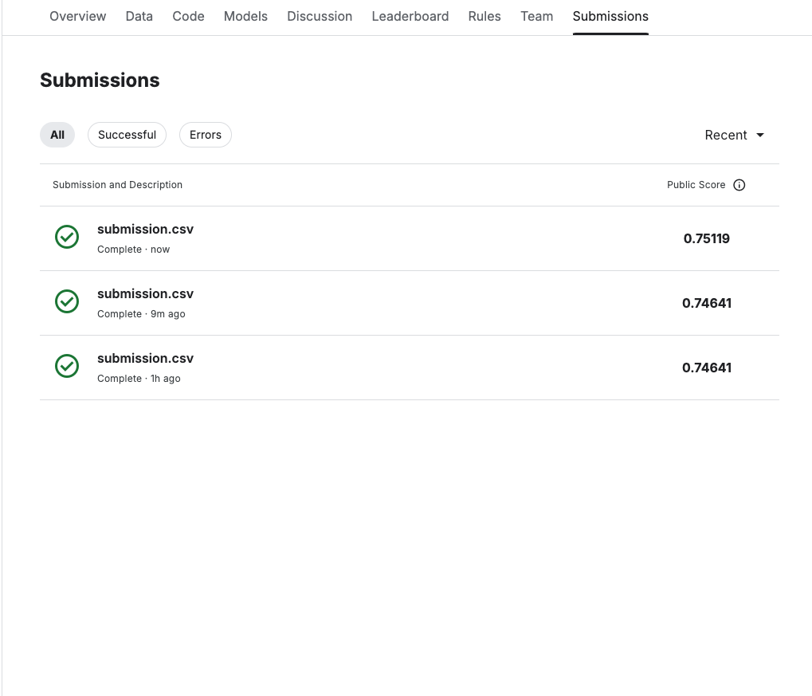

### 1.5 Conclusions and Learning

#### Conclusions

The target of this project is using ML models to predict whether a passenger can survive in the Titanic incident based on demographic data. After careful data analysis and processing, two models that are common for classification are evaluated on theri accuracy.

Although the logistic regression and random forestmodels do not have significant perforamnce difference on this task, we selected the random forest model based on its slightly better average accuracy. Then, from the feature importances of the trained random forest model, we can determine that Age, Fare, and Sex features are the 3 most impactful ones to determine passengers' survival.

In the contrary, social class is not considered as important as Age, Sex, Fare. The distribution of 'pclass' features among all predicted survivors is not very skewed towards any particular social class.

#### Learnings from the Project

After completing this project, I have learned the complete process of solving a problem with machine learning techinques. From identifying a problem to build a model and evaluation, I have learned the importance of each step and how they could affect the final conclusion. I also learned the importance of understanding and analyzing the data before applying ML techinques. Without these necessary steps, ML models cannot used to draw any conclusions.

```python
!pip install nbconvert
!jupyter nbconvert --to html notebooks/ProjectStage1.ipynb
```

```
[NbConvertApp] Converting notebook notebooks/ProjectStage1.ipynb to html
[NbConvertApp] WARNING | Alternative text is missing on 4 image(s).
[NbConvertApp] Writing 432723 bytes to notebooks/ProjectStage1.html
```